# Casestudy: Exploration of flights dataset

5 11 2018

# Purpose and research question

Suppose we are interested in the following question:

*What are the causes of flights’ delays?*

Unfortunately, we have only observational data, so there is little hope of finding causal roots of delays. But what we can hope to achieve is an understanding of *predictors* (in the statistical sense, not causal sense) of delays.

# Load data and packages

Define package list:

Start package manger package:

Load rest of packages:

# Dataset sanity check

```
#>
#> categorical variables:
#>      name     class levels      n missing
#> 1 carrier character     16 336776       0
#> 2 tailnum character   4043 334264    2512
#> 3  origin character      3 336776       0
#> 4    dest character    105 336776       0
#>                                    distribution
#> 1 UA (17.4%), B6 (16.2%), EV (16.1%) ...
#> 2 N725MQ (0.2%), N722MQ (0.2%) ...
#> 3 EWR (35.9%), JFK (33%), LGA (31.1%)
#> 4 ORD (5.1%), ATL (5.1%), LAX (4.8%) ...
#>
#> quantitative variables:
#>              name   class  min   Q1 median   Q3  max        mean
```

[output cut: 35 more lines]

From the above output, we see that there are only 3 origins, and a modeest number of carriers, some more destinations, but quite a few tailnumbers. However, it is hard to see the distribution of the qualitative variables from `inspect()`’s output.

In terms of quantitative variables, we instantly see the number of missing values. As those cases are often causing problems, that’s a helpful warning flag. Again, the distribution is not easy to reckognize.

# Distributions (univariate)

## Qualitative

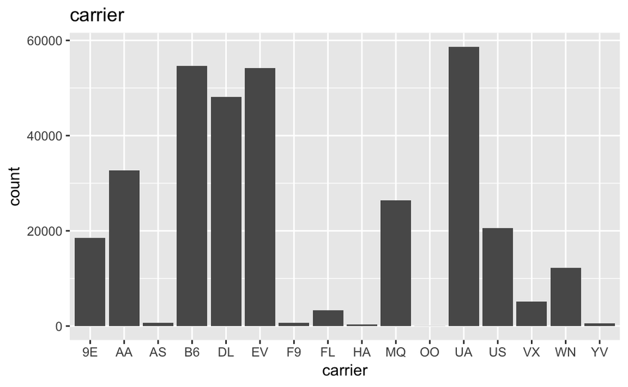

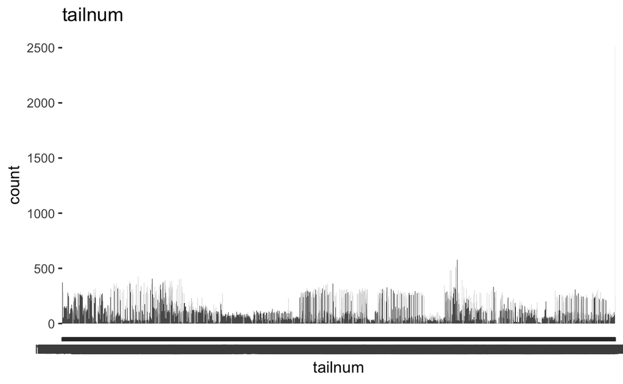

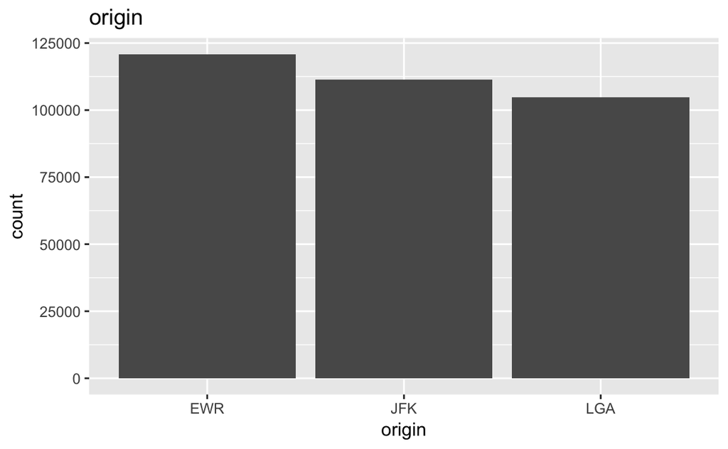

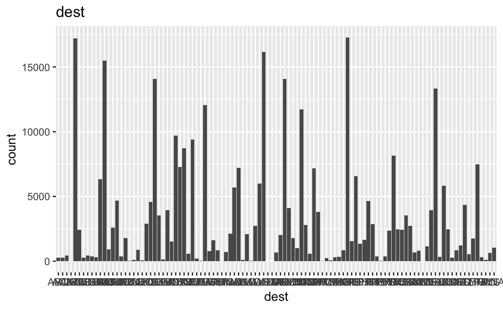

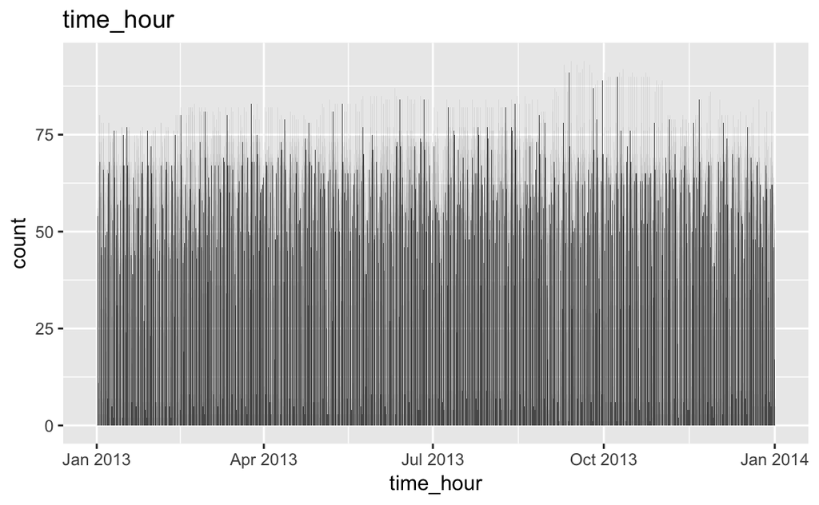

Whereas the `origin` variables does not vary much, `dest`ination does vary a lot. Similarly, the count of flights per time varies a lot. A number of values may be sparse, which can yield modeling problems.

## Quantitative

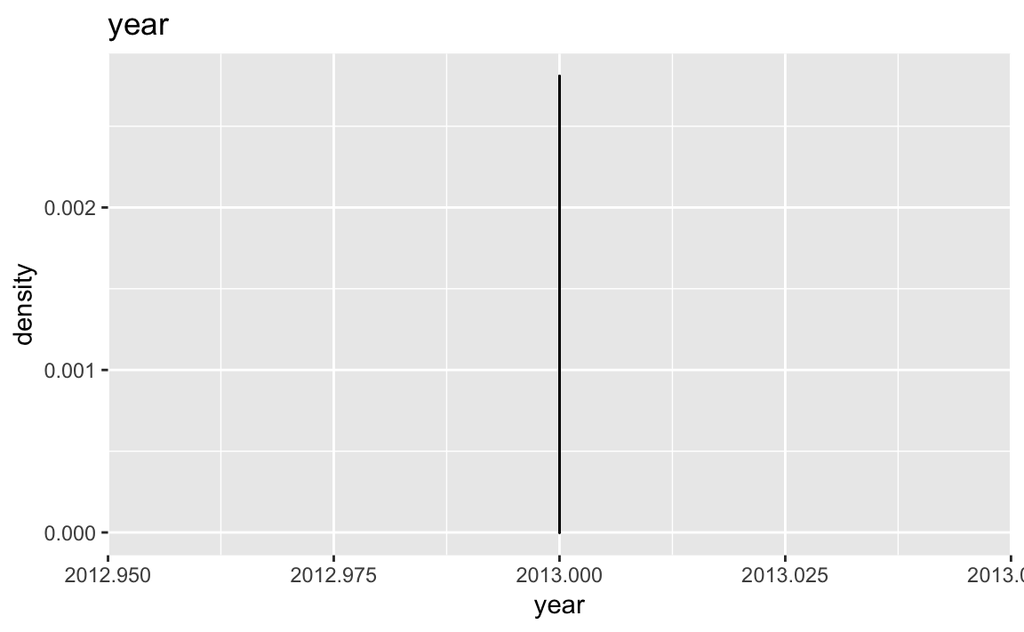

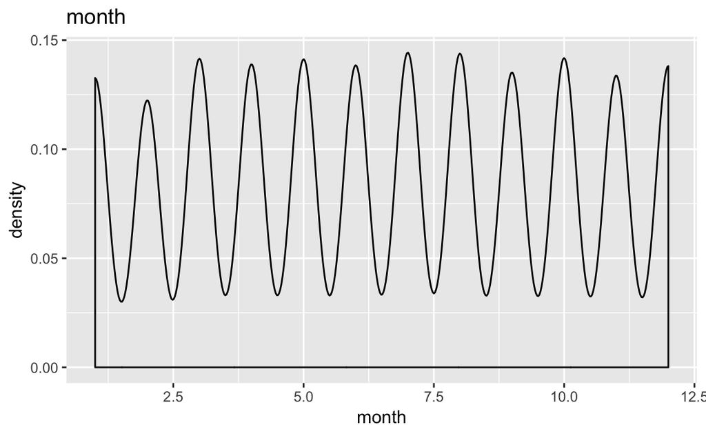

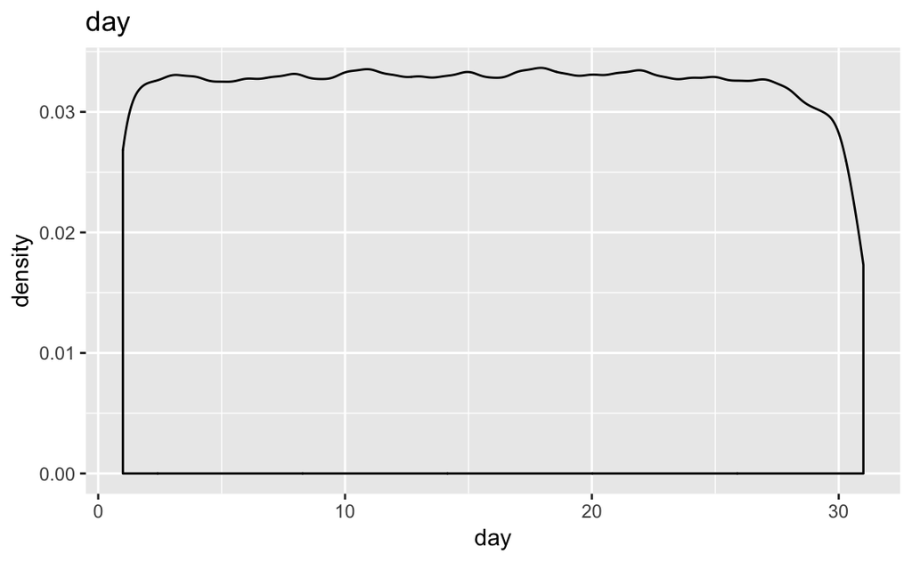

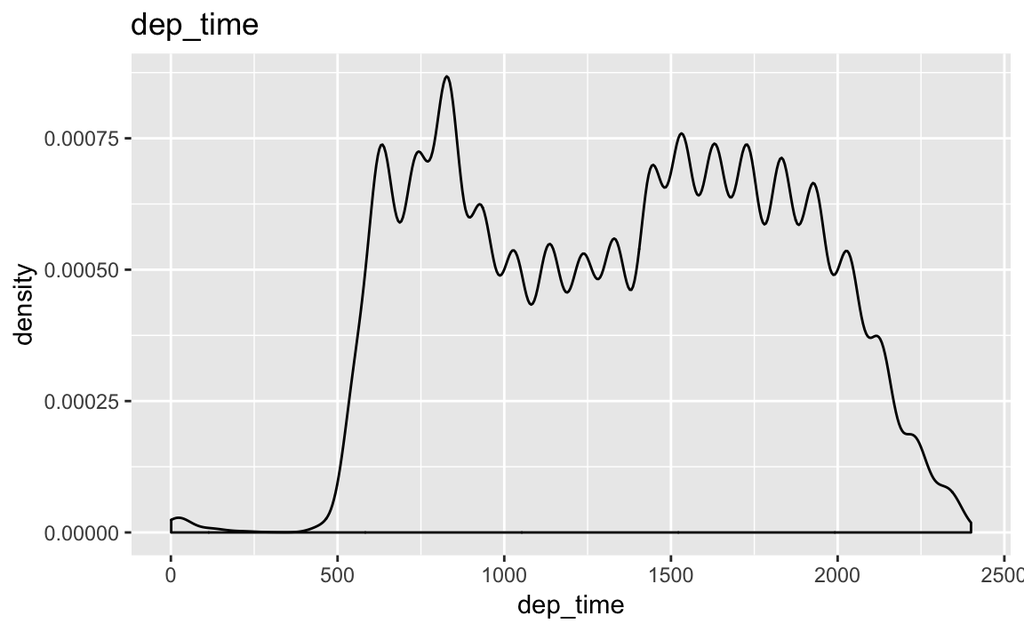

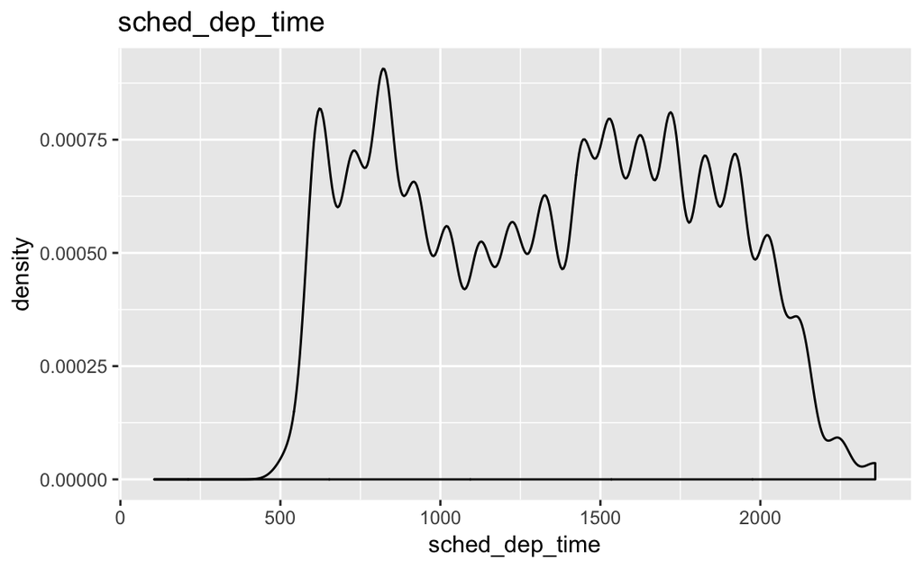

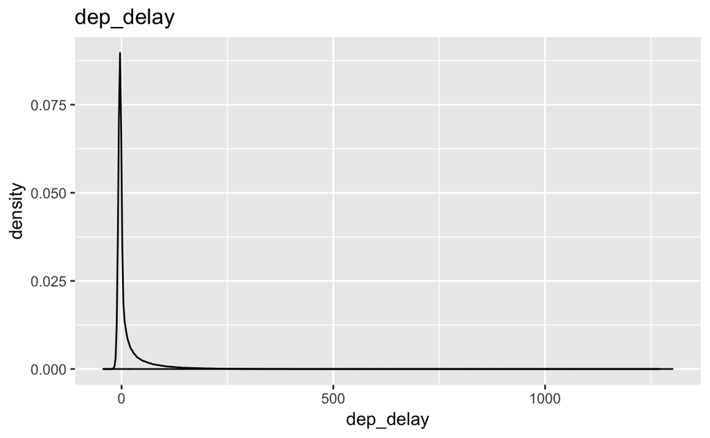

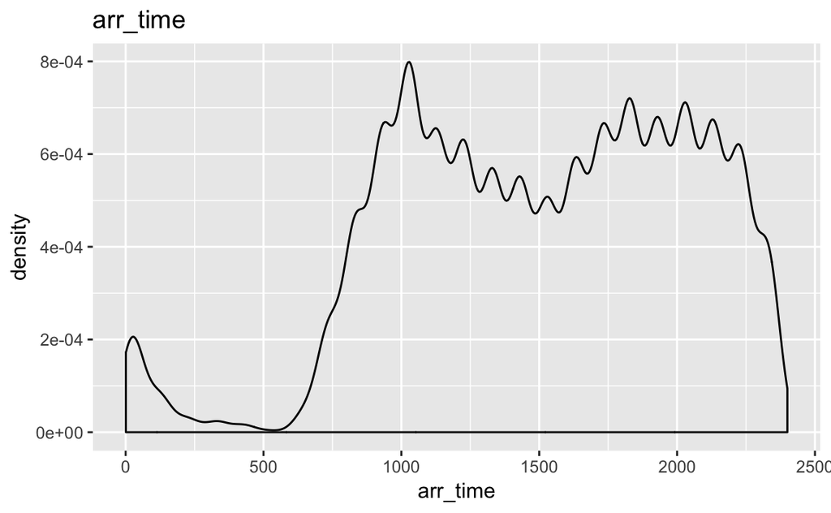

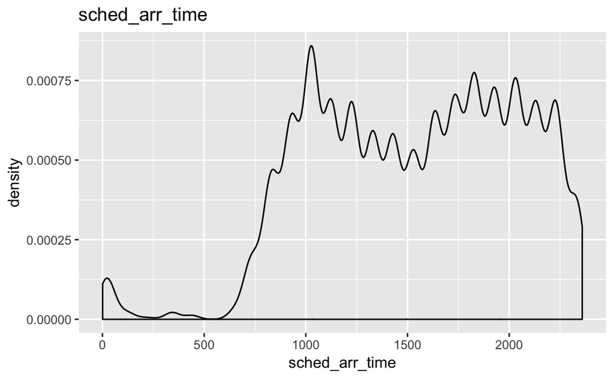

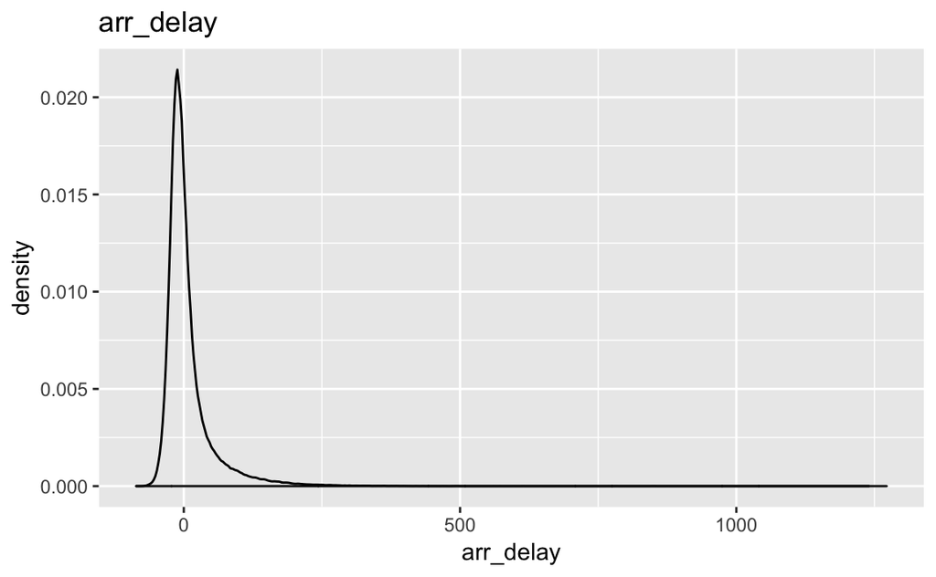

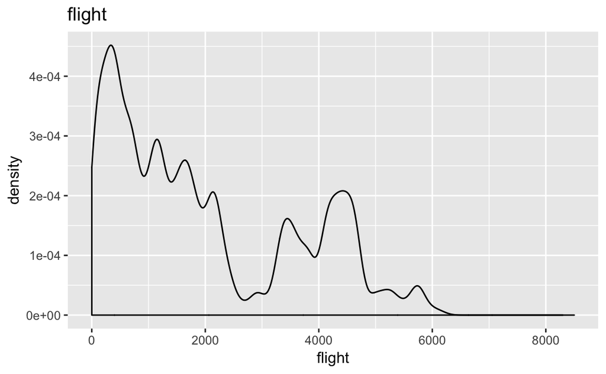

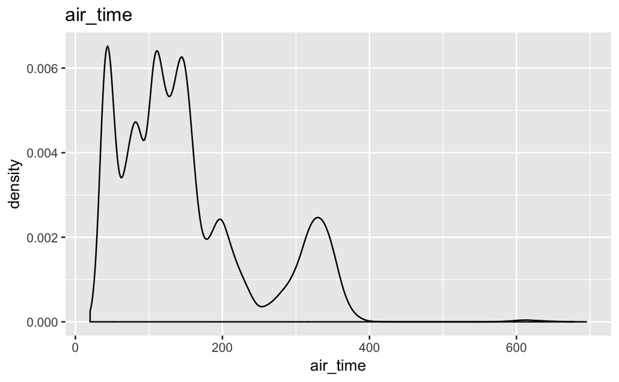

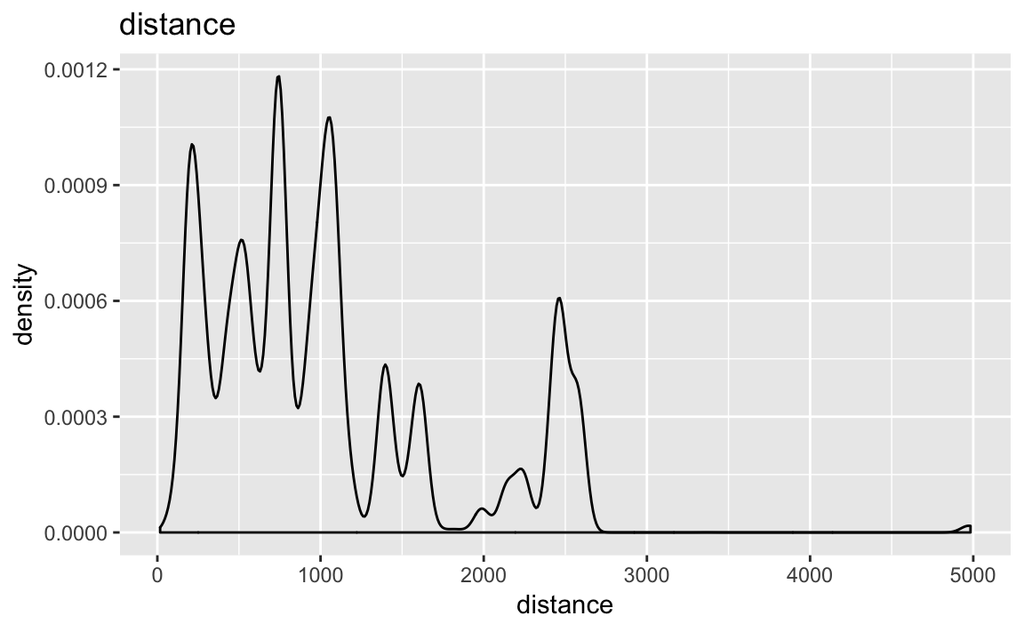

[2 more figures not shown]

Again, quite a bit of variation is present. Of central interest is of course the “response” variable, delay. We see that there are two variants of delay: arrival and departure delay. Which one is more important? It probably depends on my view: Sitting in the delayed plain, I’m interested in how much later the machines touches ground (arrival delay). Sitting at the gate, I’m hoping to get aboard as soon as possible (departure delay). Maybe departure delay is the more conservative choice: assuming that departure delay is arrival delay plus possible additional delay during ground stay, we may chose to look at departure delay.

# Descriptive statistics

Looking at the density plot, we see that `dep_delay` is skewed to the right – a loooong tail to the right. Interestingly, how big is the difference between the mean and the median?

```
#> # A tibble: 1 x 2
#>   `mean(arr_delay)` `median(arr_delay)`
#>               <dbl>               <dbl>
#> 1              6.90                  -5
```

Noteworthy, the *median* is negative (no delay), whereas the mean is positive (yes, there is delay). Imagine the communication brochure of the NYC airports!

There are three airports in NYC: JFK, LaGuardia (LGA) and Newark (EWR). How much differ the delays between those three origins? Let’s look again at the central tendencies:

```
#> # A tibble: 3 x 3
#>   origin `mean(dep_delay)` `median(dep_delay)`
#>   <chr>              <dbl>               <dbl>
#> 1 EWR                 15.0                  -1
#> 2 JFK                 12.0                  -1
#> 3 LGA                 10.3                  -3
```

The medians are close, the means, too, I’d say, but to a somewhat lesser degree.

# Start modeling

We have already stated modeling! In the last step above we reasoned that the origin of a flight may be a source of variation in delay time. Probably, we even considered the origin as a *cause* of delay. This makes sense (or is plausible at least) from a theoretical point of view. Sadly, the data does not allow for such strong conclusions. Maybe we may speak of “candidate causes” here.

More formally, one could write:

```
delay = f(origin)
```

In other words, the (departure) delay is some (unknown) function of the origin.

In R’s modeling language, we would translate the equation above as:

```
dep_delay ~ origin
```

Let’s be more precise and argue that we think there is a difference in means between the origins:

```
#> # A tibble: 3 x 5
#>   term        estimate std.error statistic   p.value
#>   <chr>          <dbl>     <dbl>     <dbl>     <dbl>
#> 1 (Intercept)    15.0      0.117     128.  0.
#> 2 originJFK      -2.99     0.168     -17.7 2.65e- 70
#> 3 originLGA      -4.72     0.172     -27.5 3.33e-166
```

The results show us, one the one hand, the same as the summary (via `mean()`) above. But, on the other hand, do infer that the differences between the means are substantial and should be expected to happen in future samples, too. More on that later.

# Is `distance` an important predictor of delay?

## By flight

One may argue that the farer away the destination, the more likely something happens, resulting in (more) delay. Let’s check that. First, visually:

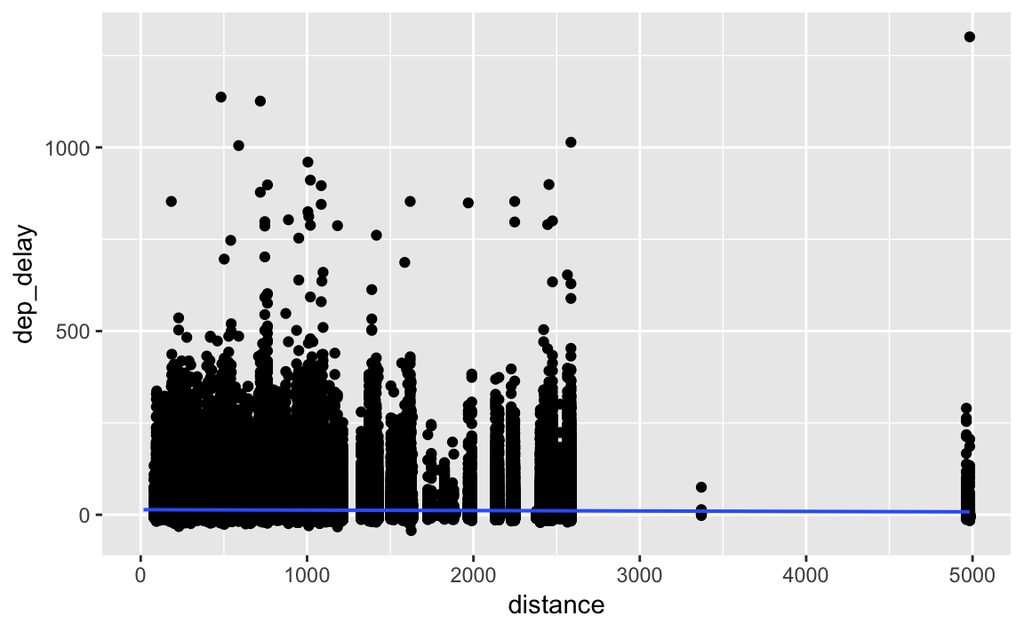

Due to the quite large data set, the `ggplot()` plotting takes a while. Maybe it would be practical to see if we can get the same (or similar) results based on a smaller sample?

```
#> # A tibble: 2 x 3
#>   rowname   distance dep_delay
#>   <chr>        <dbl>     <dbl>
#> 1 distance   NA        -0.0217
#> 2 dep_delay  -0.0217   NA
```

Let’ group the correlation by origin:

```
#> # A tibble: 3 x 2
#>   origin cor_delay_dist
#>   <chr>           <dbl>
#> 1 EWR           -0.0361
#> 2 JFK           -0.0398
#> 3 LGA            0.0114
```

As shown by the scatterplot, there’s no bivariate correlation. Notice that we are only looking at lineare covariation and that we did not take any other variables into account (possibly altering the association).

Again, instead of correlating the two variables, it is more useful to model delay as a function of distance:

```
#> # A tibble: 4 x 5
#>   term             estimate std.error statistic   p.value
#>   <chr>               <dbl>     <dbl>     <dbl>     <dbl>
#> 1 (Intercept)         16.8     0.157      107.  0.
#> 2 I(distance/1000)    -1.60    0.0988     -16.2 9.43e- 59
#> 3 originJFK           -2.66    0.170      -15.7 3.09e- 55
#> 4 originLGA           -5.21    0.174      -29.9 3.80e-196
```

## By plane

In the last step, or up until now, we considered a flight to be the unit of observation. But we can also see a plane as the unit of observation thereby pivoting our research question somewhat? *May distance to destination delay a plane?*

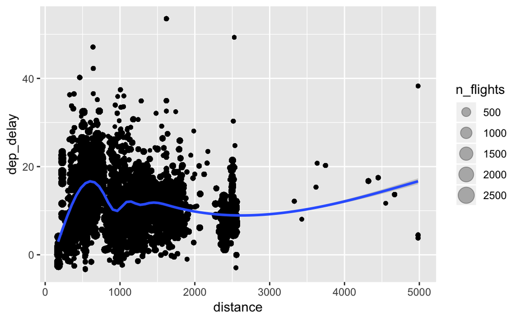

Again, there appears to be no strong pattern, no strong assocation.

# Time trends

## Is it the winter?

One futher idea is that the winter may cause troubles and delays. Let’s check that. Say, winter in NYC starts in November (11) and comes to an end by end of March (3).

```
#> # A tibble: 1 x 1
#>   cor_delay_dist
#>            <dbl>
#> 1        -0.0387
```

Winter does not seem to play a strong role. Let’s look at it from a slightly different angle:

```
#> # A tibble: 2 x 3
#>   winter `mean(dep_delay)` `median(dep_delay)`
#>   <lgl>              <dbl>               <dbl>
#> 1 FALSE               13.6                  -2
#> 2 TRUE                11.3                  -1
```

Not really a difference between winter and non-winter. But may be there’s an interaction with origin – amounting to say that in some origins, winter may play a role?

```
#> # A tibble: 6 x 4
#> # Groups:   winter [?]
#>   winter origin `mean(dep_delay)` `median(dep_delay)`
#>   <lgl>  <chr>              <dbl>               <dbl>
#> 1 FALSE  EWR                15.3                   -1
#> 2 FALSE  JFK                13.5                   -1
#> 3 FALSE  LGA                11.7                   -3
#> 4 TRUE   EWR                14.8                    0
#> 5 TRUE   JFK                10.1                   -2
#> 6 TRUE   LGA                 8.33                  -3
```

There’s a convenient function from package `mosaic` that gives back the difference in mean between two groups, `diffmean()`:

```
#> # A tibble: 1 x 2
#>   diff_mean_winter diff_md_winter
#>              <dbl>          <dbl>
#> 1            -2.32              1
```

For other statistics, we need to wrap the statistic in `diff(statistic(...))`.

## Delay per month

Similarly, one may ask: Maybe it’ not winter per se, but there may be months where the dalys pile up. Let’s see.

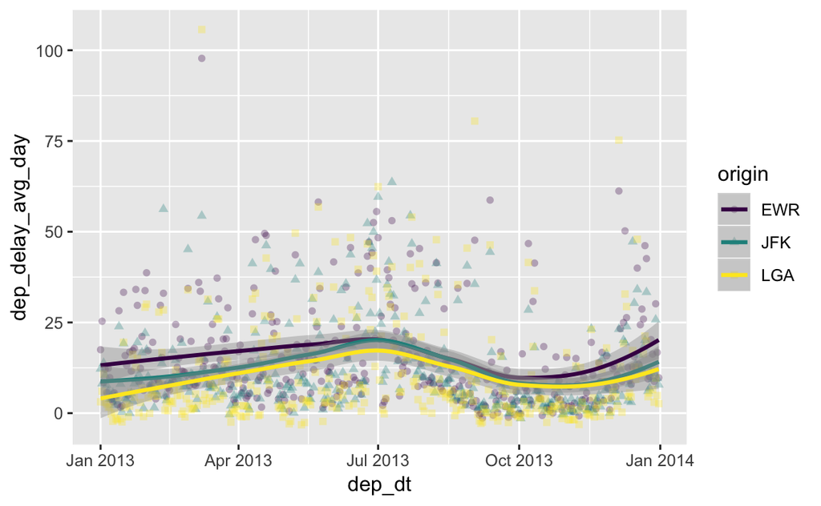

So best time to fly was Octobre, and the christmas seasons appears to be problematic – and the summer.

We can have a look at the numbers, but probably a diagram will be more elusive. Let’s start with the statistics.

```
#> # A tibble: 12 x 5
#>    month delay_m delay_md delay_sd delay_iqr
#>    <int>   <dbl>    <dbl>    <dbl>     <dbl>
#>  1     1   10.0        -2     36.4        13
#>  2     2   10.8        -2     36.3        14
#>  3     3   13.2        -1     40.1        17
#>  4     4   13.9        -2     43.0        17
#>  5     5   13.0        -1     39.4        17
#>  6     6   20.8         0     51.5        26
#>  7     7   21.7         0     51.6        27
#>  8     8   12.6        -1     37.7        17
#>  9     9    6.72       -3     35.6         8
#> 10    10    6.24       -3     29.7        10
#> 11    11    5.44       -3     27.6         9
#> 12    12   16.6         0     41.9        23
```

Interestingly, the summer times are problematic. Why can this be? Maybe people fly a lot to their vacation locations? Maybe the vacation flights are less regular and thus not so well organized? We have no data on that, all we can state is that there is evidence that summer is problematic.

Another helpful visualizatin is the boxplot:

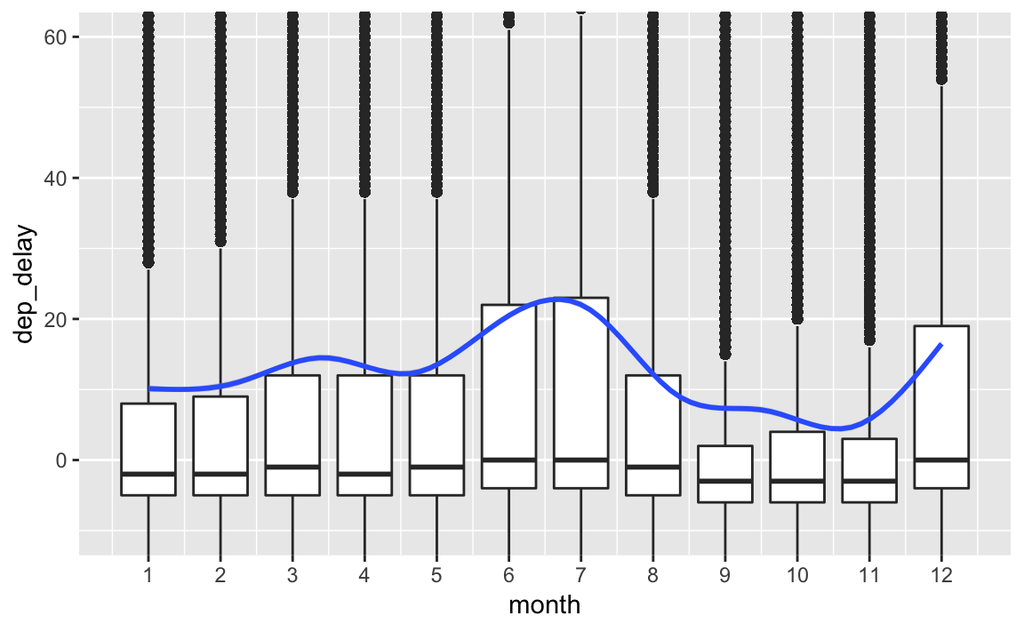

## Christmas delay

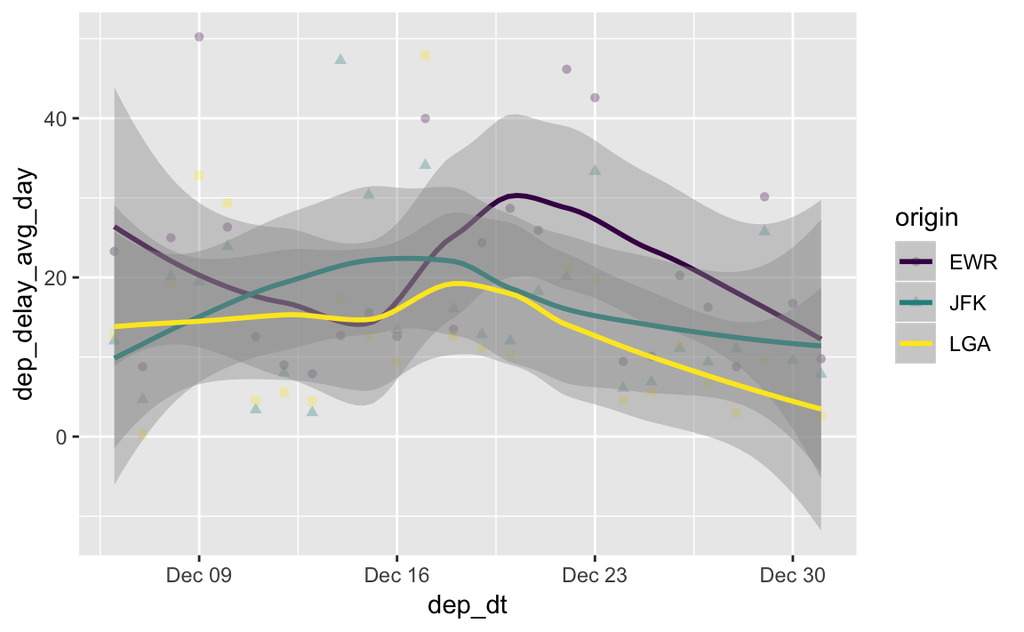

The diagram is not much telling. Let’s try a boxplot per month:

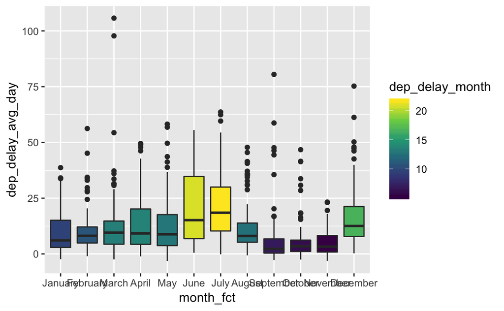

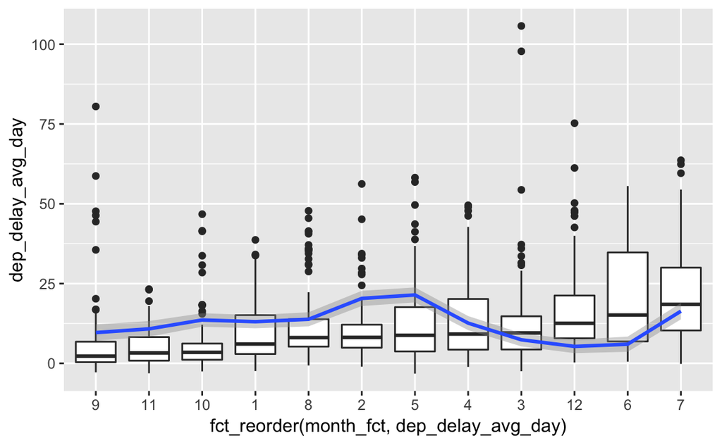

## Delay per time of the day

Let’s check whether delays add up during the day, a popular opinion among travellers.

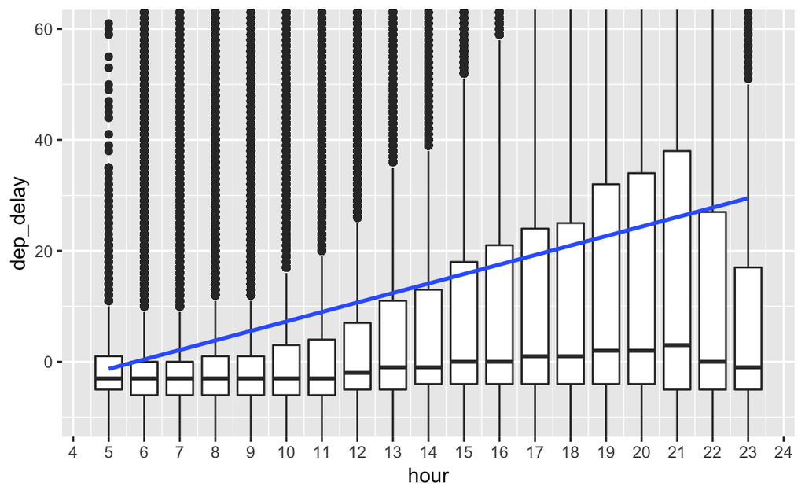

This looks like we hit something. Well, the theory was not too surprising, but, hey, it kind of worked. Notice that the mean and the median spread out substantially, indicating the presence of extreme values (as being obvious in the boxplot outliers).

Let’s check how much variance is explained by this model:

```
#> [1] 0.03929351
```

# Bivariate plots for many (numeric) predictors

Plotting many bivariate scatter plots can take a lot of time, if the sample is large. So let’s check if we can reduce the sample size without losing (much) information.

```
#> # A tibble: 5 x 6
#>   rowname         dep_delay sched_dep_time    month      day air_time
#>   <chr>               <dbl>          <dbl>    <dbl>    <dbl>    <dbl>
#> 1 dep_delay       NA            NA         NA       NA             NA
#> 2 sched_dep_time   0.199        NA         NA       NA             NA
#> 3 month           -0.0201       -0.00457   NA       NA             NA
#> 4 day              0.000420     -0.0000144  0.00294 NA             NA
#> 5 air_time        -0.0224       -0.0155     0.0109   0.00224       NA
```

Let’s compare that to a smaller sample of, say, 1000 observations:

```
#> # A tibble: 5 x 6
#>   rowname        dep_delay sched_dep_time     month       day air_time
#>   <chr>              <dbl>          <dbl>     <dbl>     <dbl>    <dbl>
#> 1 dep_delay        NA            NA        NA        NA             NA
#> 2 sched_dep_time    0.167        NA        NA        NA             NA
#> 3 month            -0.0495        0.0558   NA        NA             NA
#> 4 day               0.0741       -0.00661  -0.00287  NA             NA
#> 5 air_time         -0.0452        0.00800  -0.0144   -0.00814       NA
```

Now let’s look at the differences for the correlation coefficients:

```
#> # A tibble: 5 x 6
#>   rowname        dep_delay sched_dep_time    month     day air_time
#>   <chr>              <dbl>          <dbl>    <dbl>   <dbl>    <dbl>
#> 1 dep_delay        NA            NA       NA       NA            NA
#> 2 sched_dep_time    0.0319       NA       NA       NA            NA
#> 3 month             0.0295       -0.0603  NA       NA            NA
#> 4 day              -0.0737        0.00659  0.00581 NA            NA
#> 5 air_time          0.0228       -0.0235   0.0253   0.0104       NA
```

None is above 0.1.

What’s the average difference in correlation coefficients?

```
#> [1] -0.002530955
```

On average, the correlations coefficients are very similar.

Now this plot shows the specified bivariate scatter plots

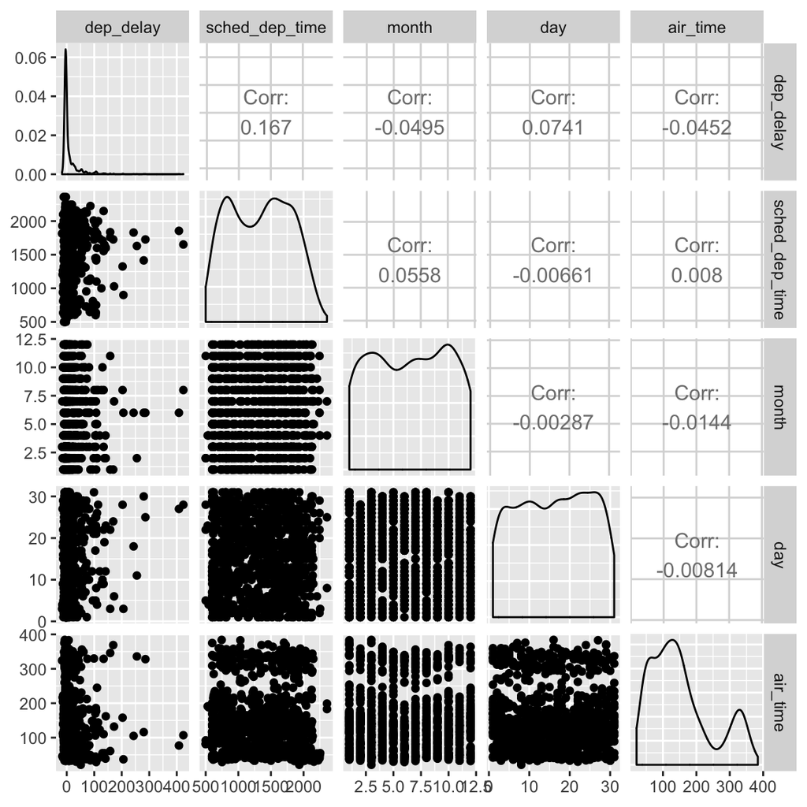

# Wheather

Maybe the weather conditions explain the delays?

```
#> Observations: 26,115
#> Variables: 15
#> $ origin     <chr> "EWR", "EWR", "EWR", "EWR", "EWR", "EWR", "EWR", "E...
#> $ year       <dbl> 2013, 2013, 2013, 2013, 2013, 2013, 2013, 2013, 201...
#> $ month      <dbl> 1, 1, 1, 1, 1, 1, 1, 1, 1, 1, 1, 1, 1, 1, 1, 1, 1, ...
#> $ day        <int> 1, 1, 1, 1, 1, 1, 1, 1, 1, 1, 1, 1, 1, 1, 1, 1, 1, ...
#> $ hour       <int> 1, 2, 3, 4, 5, 6, 7, 8, 9, 10, 11, 13, 14, 15, 16, ...
#> $ temp       <dbl> 39.02, 39.02, 39.02, 39.92, 39.02, 37.94, 39.02, 39...
#> $ dewp       <dbl> 26.06, 26.96, 28.04, 28.04, 28.04, 28.04, 28.04, 28...
#> $ humid      <dbl> 59.37, 61.63, 64.43, 62.21, 64.43, 67.21, 64.43, 62...
#> $ wind_dir   <dbl> 270, 250, 240, 250, 260, 240, 240, 250, 260, 260, 2...
#> $ wind_speed <dbl> 10.35702, 8.05546, 11.50780, 12.65858, 12.65858, 11...
#> $ wind_gust  <dbl> NA, NA, NA, NA, NA, NA, NA, NA, NA, NA, NA, NA, NA,...
#> $ precip     <dbl> 0, 0, 0, 0, 0, 0, 0, 0, 0, 0, 0, 0, 0, 0, 0, 0, 0, ...
#> $ pressure   <dbl> 1012.0, 1012.3, 1012.5, 1012.2, 1011.9, 1012.4, 101...
#> $ visib      <dbl> 10, 10, 10, 10, 10, 10, 10, 10, 10, 10, 10, 10, 10,...
#> $ time_hour  <dttm> 2013-01-01 01:00:00, 2013-01-01 02:00:00, 2013-01-...
```

Let’s join the weather and the flights data. Let’s map the weather condition to the hour of the flight departure.

We first constrct a column that codes the hour of departure:

Then we merge (join) the two data frames using the date and time variables as IDs.

```
#> # A tibble: 4 x 5
#>   term        estimate std.error statistic p.value
#>   <chr>          <dbl>     <dbl>     <dbl>   <dbl>
#> 1 (Intercept)   22.2     0.215       103.        0
#> 2 wind_speed     0.417   0.00733      56.9       0
#> 3 visib         -1.57    0.0215      -72.9       0
#> 4 precip        78.7     1.41         55.8       0
#> [1] 0.01524165
#> # A tibble: 1 x 11
#>   r.squared adj.r.squared sigma statistic p.value    df  logLik    AIC
#> *     <dbl>         <dbl> <dbl>     <dbl>   <dbl> <int>   <dbl>  <dbl>
#> 1    0.0152        0.0152  39.9     5060.       0     4 -5.01e6 1.00e7
#> # ... with 3 more variables: BIC <dbl>, deviance <dbl>, df.residual <int>
```

The amount of explained variance is still very low. We have not yet found a strong explanation for the delays.

# Geoplotting

Rather for curiosity than for actual insight to our research question, let’s draw a map of the flight routes, indicating the number of flights per route by color or thickness of lines.

Join lat-long-data of the destination airports:

Now we build a data frame showing the origins, destinations and number of flights between these points:

```
#> # A tibble: 6 x 7
#> # Groups:   dest [5]
#>   dest  origin     n   long   lat long_origin lat_origin
#>   <chr> <chr>  <int>  <dbl> <dbl>       <dbl>      <dbl>
#> 1 ABQ   JFK      254 -107.   35.0       -73.8       40.6
#> 2 ACK   JFK      265  -70.1  41.3       -73.8       40.6
#> 3 ALB   EWR      439  -73.8  42.7       -74.2       40.7
#> 4 ANC   EWR        8 -150.   61.2       -74.2       40.7
#> 5 ATL   EWR     5022  -84.4  33.6       -74.2       40.7
#> 6 ATL   JFK     1930  -84.4  33.6       -73.8       40.6
```

Now we plot a map with lines connceting origins and destinations:

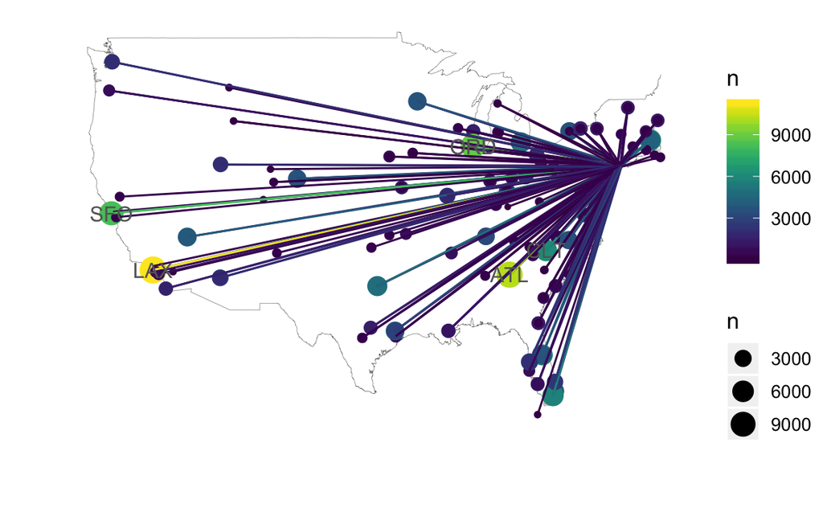

# Stop and think

Our searching was not really successful so far. We have not identified important sources of variation in delay. Let’s recknognize this fact.

Second, we should recknognize that we are quite explorative: There’s no strong theory guiding our statistical analysis. It is probably true that many other analysis in the social sciences suffer from this problem, but it is still undesirable. Given one applies statistical magigcal sauce long enough, some effects are bound to pop up. We would have move more confidence in our results if they were driven by a strong theory. Otherwise we are prone to overfit the data.

Given the lack of a theory that tells us which predictors are important, what to do? There are of course a number of statistical approaches for selecting predictors including stepwise procedures, considering the bivariate correlation, variable importance of machine learning approaches, information criteria, and more.

However, a theory based approach has the advantage of better understanding what we are modeling, of being able of making sense of it and thus possibly using it elsewhere including explaining it to someone.

Now, the idea of blaiming the “nature” for the delays have failed. It is not the weather, as it appears, nor the distance, nor the time of the year. So, it it is not nature, it must be human made. Although we are lacking data to fully explore the faultyness of human nature, we can at least check how much variation is explained by using the destination as predictor. The rationale is here that some folks at some places do it well, whereas other folks at other places (destinations) have other things to do (and thus produce delays).

# The human-made-disaster hypothesis

Let’s call the “human-made-disaster hypothesis” the belief, that delay is human made, somehow. We don’t exacly know how, but we speculate people have different ability in (not) producing delay. Further, we assume that some places, being complex systems with complex interactions, are more competent in producing delays. On this base, we reckon that the differences between destinations (and secondly, origins) explain a big part of the observed delays. On a similar base, the persons at the carriers (airlines) may exert an impact on the delays.

```
#> [1] 0.01461551
```

Sadly, this hypothesis does not explain much of the delays either.

There’s one more important source of humanness: the pilot. Unfortunately, we don’t have data on that. Maybe we can use the tail number of a plain as a proxy – assuming that one pilot tends to use the same machine.

Before we start: how many different machines are there?

```
#> [1] 4044
```

Quite a bit. How many machines do operate often and how many do not leave their parking lot? To make things quicker, let’s focus on those who have flown at least 100 times.

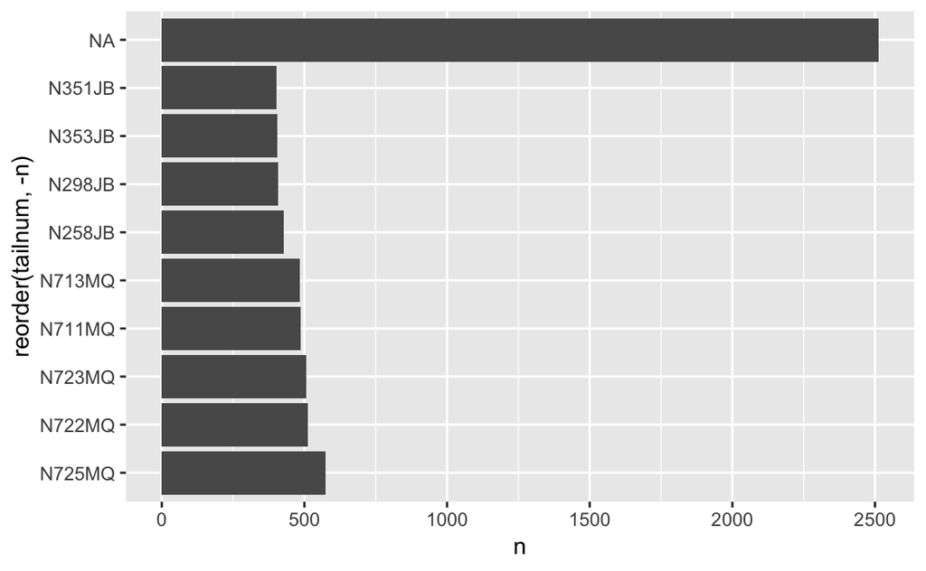

# The date-time hypothesis

Another frequent idea is that delay times build up over the days, so that’s time of the day which is responsible for delays.